# Tarea 1

Siga el siguiente documento y escriba el código en las secciones señaladas.

### Autores

- Efrén Jiménez

### Modificado por

- Jorge Porras Araya

## Análisis del Problema

Este conjunto de datos contiene precios de venta de casas para el Condado de King, que incluye Seattle. Incluye casas vendidas entre mayo de 2014 y mayo de 2015.

Es un gran conjunto de datos para evaluar modelos de regresión simples.

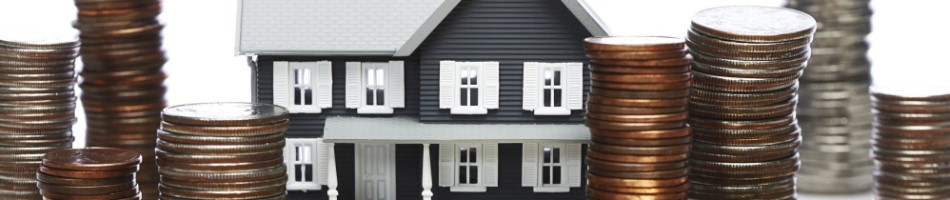

Proceso ROC

## Análisis del dataset

Lea el dataset con la función read.csv y guardelo en una variable

Ejemplo:

`casas <- read.csv('kc_house_data.csv', header = T, na.strings = '?')`

```r
KingHouses <- read.csv('kc_house_data.csv', header = T, na.strings = '?')
```

Utilice la función summary sobre el dataset

Ejemplo:

`summary(casas)`

```r
summary(KingHouses)
```

```
##        id                         date          price
##  Min.   :1.200e+06   20140623T000000:  57   Min.   : 115000
##  1st Qu.:2.155e+09   20140708T000000:  52   1st Qu.: 370000
##  Median :3.905e+09   20140826T000000:  52   Median : 495000
##  Mean   :4.604e+09   20140718T000000:  51   Mean   : 534373
##  3rd Qu.:7.335e+09   20140709T000000:  50   3rd Qu.: 664963
##  Max.   :9.900e+09   20140714T000000:  50   Max.   :1950000
##                      (Other)        :7960
##     bedrooms        bathrooms     sqft_living      sqft_lot
##  Min.   : 0.000   Min.   :0.00   Min.   : 500   Min.   :    520
##  1st Qu.: 3.000   1st Qu.:1.75   1st Qu.:1490   1st Qu.:   5350
##  Median : 3.000   Median :2.25   Median :2010   Median :   7980
##  Mean   : 3.414   Mean   :2.18   Mean   :2157   Mean   :  17610
##  3rd Qu.: 4.000   3rd Qu.:2.50   3rd Qu.:2660   3rd Qu.:  11675
##  Max.   :10.000   Max.   :6.00   Max.   :7730   Max.   :1164794
##
##      floors        waterfront            view          condition
##  Min.   :1.000   Min.   :0.000000   Min.   :0.0000   Min.   :1.000
##  1st Qu.:1.000   1st Qu.:0.000000   1st Qu.:0.0000   1st Qu.:3.000
##  Median :1.500   Median :0.000000   Median :0.0000   Median :3.000
##  Mean   :1.529   Mean   :0.002176   Mean   :0.1875   Mean   :3.376
##  3rd Qu.:2.000   3rd Qu.:0.000000   3rd Qu.:0.0000   3rd Qu.:4.000
##  Max.   :3.500   Max.   :1.000000   Max.   :4.0000   Max.   :5.000
##
##      grade          sqft_above   sqft_basement       yr_built
##  Min.   : 4.000   Min.   : 500   Min.   :   0.0   Min.   :1900
##  1st Qu.: 7.000   1st Qu.:1230   1st Qu.:   0.0   1st Qu.:1957
##  Median : 8.000   Median :1620   Median :   0.0   Median :1979
##  Mean   : 7.782   Mean   :1871   Mean   : 285.5   Mean   :1975
##  3rd Qu.: 8.000   3rd Qu.:2360   3rd Qu.: 570.0   3rd Qu.:1999
##  Max.   :12.000   Max.   :7420   Max.   :3260.0   Max.   :2015
##
##   yr_renovated        zipcode           lat             long
##  Min.   :   0.00   Min.   :98001   Min.   :47.16   Min.   :-122.5
##  1st Qu.:   0.00   1st Qu.:98034   1st Qu.:47.53   1st Qu.:-122.3
##  Median :   0.00   Median :98070   Median :47.61   Median :-122.2
##  Mean   :  67.04   Mean   :98077   Mean   :47.61   Mean   :-122.2
##  3rd Qu.:   0.00   3rd Qu.:98118   3rd Qu.:47.71   3rd Qu.:-122.1
##  Max.   :2015.00   Max.   :98199   Max.   :47.78   Max.   :-121.3
##
##  sqft_living15    sqft_lot15
##  Min.   : 399   Min.   :   651
##  1st Qu.:1500   1st Qu.:  5400
##  Median :1900   Median :  7971
##  Mean   :2051   Mean   : 14875
##  3rd Qu.:2470   3rd Qu.: 10862
##  Max.   :5790   Max.   :858132
##
```

```r
#librerías utilizadas
library(caTools)

#Librería de gráficos
library(ggplot2)
#Evitar mostrar warning messages
options(warn=-1)
```

Cargue en una variable las columnas ‘price’ y ‘sqft_living’

Ejemplo

`casas <-casas[,c(3,6)]`

```r
# Escriba su código aqui
KingHousesMin <- KingHouses[,c(3,6)]
```

Utilice la función summary sobre la nueva variable

```r
summary(KingHousesMin)
```

```
##      price          sqft_living
##  Min.   : 115000   Min.   : 500
##  1st Qu.: 370000   1st Qu.:1490
##  Median : 495000   Median :2010
##  Mean   : 534373   Mean   :2157
##  3rd Qu.: 664963   3rd Qu.:2660
##  Max.   :1950000   Max.   :7730
```

Aplique la función de correlación para obtener las correlaciones entre las columnas seleccionadas (price, sqft_living)

Ejemplo:

`cor(casas)`

```r
# Escriba su código aqui
cor(KingHousesMin)
```

```
##                 price sqft_living
## price       1.0000000   0.9586948
## sqft_living 0.9586948   1.0000000
```

### Interpretando los resultados de la correlación

### Tipos de relación

- -1,00 = Correlación negativa perfecta
- -0,90 = Correlación negativa muy fuerte
- -0,75 = Correlación negativa considerable
- -0,50 = Correlación negativa media
- -0,10 = Correlación negativa débil
- 0,00 = No existe correlación lineal alguna entre las variables
- 0,10 = Correlación positiva débil
- 0,50 = Correlación positiva media
- 0,75 = Correlación positiva considerable
- 0,90 = Correlación positiva muy fuerte
- 1,00 = Correlación positiva perfecta

Existen varios métodos para calcular la correlación, la función ‘cor’ permite especificar el tipo de método mediante el parámetro ‘method’

Ejemplo

`cor(casas, method='pearson')`

`cor(casas, method='spearman')`

```r
cor(KingHousesMin, method = 'pearson')
```

```
##                 price sqft_living
## price       1.0000000   0.9586948
## sqft_living 0.9586948   1.0000000
```

```r
cor(KingHousesMin, method = 'spearman')
```

```
##                 price sqft_living
## price       1.0000000   0.9593223
## sqft_living 0.9593223   1.0000000
```

### Visualización

Por último vamos a visualizar los datos del dataset con respecto a las columnas anteriormente seleccionadas (price, sqft_living) para observar si existe alguna tendencia que podamos predecir.

Con la función plot cree un gráfico de dispersión, asigne la columna ‘price’ al eje Y y la columna sqft_living al eje X

Ejemplo

`plot(y = casas$price,x = casas$sqft_living, main = 'Relación entre Precio y Metros cuadrados', ylab = 'price', xlab = 'sqft_living')`

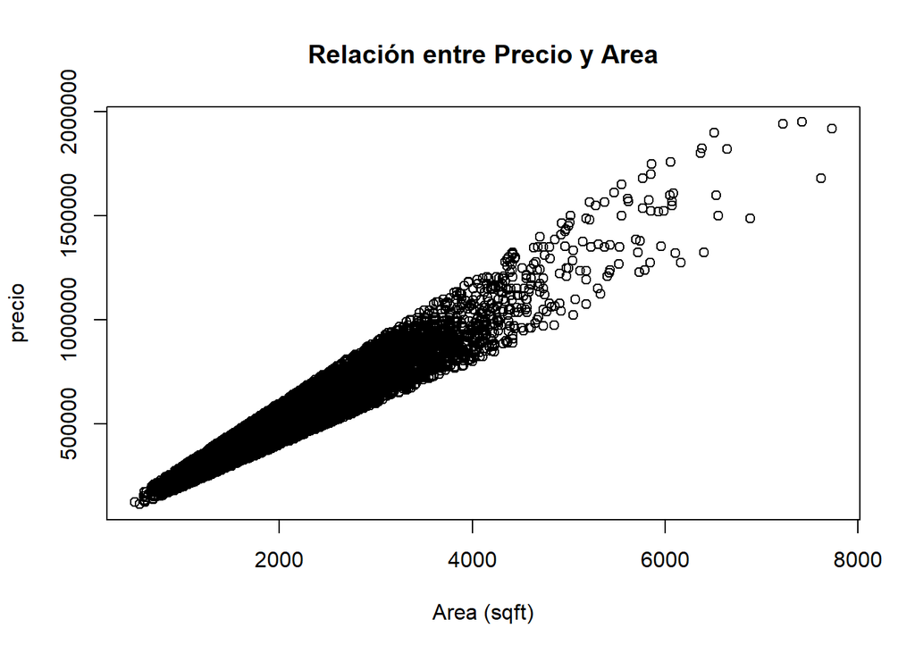

```r
plot(y = KingHousesMin$price,x = KingHousesMin$sqft_living, main = 'Relación entre Precio y Area', ylab = 'precio', xlab = 'Area (sqft)')
```

## Conclusiones

Como se puede observar tanto en la gráfica como en las correlaciones, existe una tendencia clara en el aumento del precio de las viviendas con respecto a los metros cuadrados. Con este pequeño análisis de los datos podemos elegir las variables predictoras y el modelo inicial, en este caso podemos elegir utilizar una regresión lineal simple utilizando la columna ‘sqft_living’ como variable predictora.